# Python Plotting Challenge

# Categorical plots

Okay, so let’s just think about locomotion for now. Maybe there’s a difference in locomoation as a function of gender. Plot a bar plot showing the average locomotion score and 95% CI for each gender.

Remember, you might want to recode the variable to get your plot to show descriptive factor levels!

```python
garcia["gender"] = garcia["gender"].replace({1:'Female',2:'Male'})
```

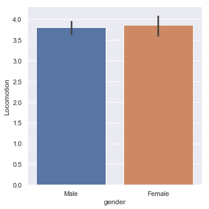

```python
sns.catplot(x="gender",y="Locomotion",data=garcia,kind="bar");
```

Great! Sometimes bar plots can hide the distribution of the raw data though. Let’s plot just the raw datapoints broken down by gender:

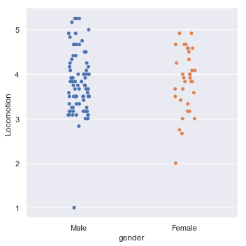

```python
sns.catplot(x="gender",y="Locomotion",data=garcia,kind="strip");
```

What if we wanted to put both of these plots on top of each other? Try using the individual functions for these catplots to create a single graph. Hint: making the bars slightly lighter than the points helps to make all of the points visible.

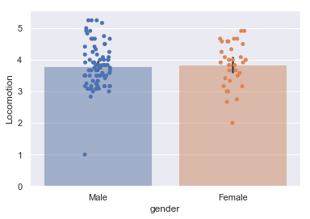

```python
sns.barplot(x="gender",y="Locomotion",data=garcia,alpha=0.5)
sns.stripplot(x="gender",y="Locomotion",data=garcia);
```

Okay, so while there might not be huge gender difference in this dataset on locomotion, maybe locomotion predicts different things in males and females.

Make a scatter plot + linear regression line (with confidence interval) with locomotion on the x axis and PWB on the y axis, but this time break this relationship out by gender

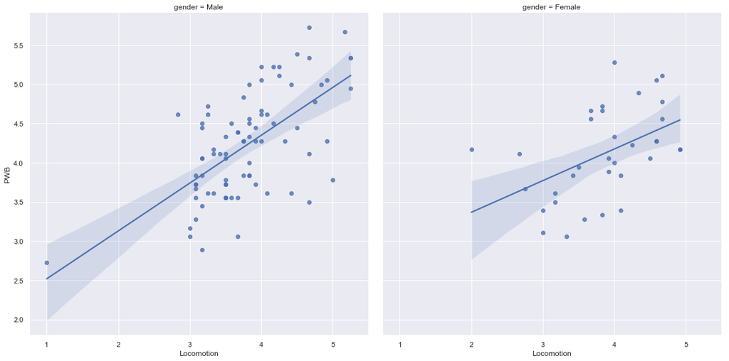

```python
sns.lmplot(x="Locomotion",y="PWB",data=garcia,height=8,truncate=True,col="gender",col_wrap=2);
```

Okay, let’s switch it up and look at how PWB predicts academic achievement broken down by gender:

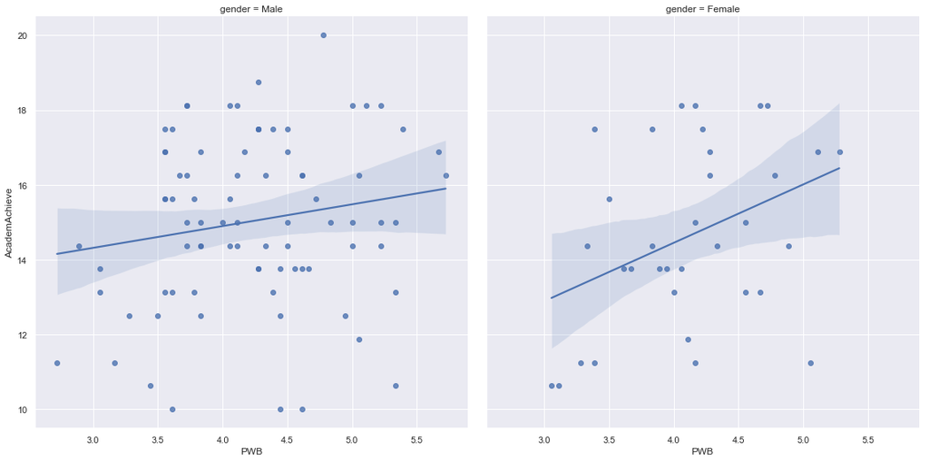

```python
sns.lmplot(x="PWB",y="AcademAchieve",data=garcia,height=8,truncate=True,col="gender",col_wrap=2);
```

Okay, now let’s say we want to make this one look nice! Change the style, font, colors, and labels:

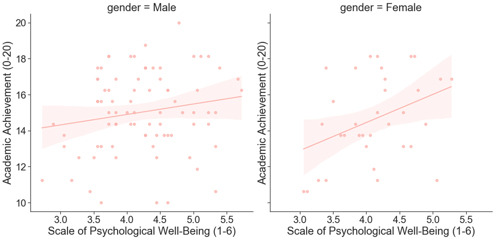

```python
sns.set(style="ticks",font="Arial",palette="Pastel1",font_scale=2)

g = sns.lmplot(x="PWB",y="AcademAchieve",data=garcia,height=8,truncate=True,col="gender",col_wrap=2)
for i in range(2):
    g.axes[i].set_xlabel('Scale of Psychological Well-Being (1-6)')
    g.axes[i].set_ylabel('Academic Achievement (0-20)')
```